# Exploring a Synthetic SSc Cohort

Data Understanding, Application, and Data Quality

Semion Leyn

2026-09-11

# Semion Leyn, PhD

- Production grade bioinformatics pipelines (HPC and Cloud)
- Data solutions co-development with clinical partners (e.g. Roswell Park - NYS CLEP validation).
- Worked in:
  - Russian Academy of Sciences (academy)
  - SBP Medical discovery institute (academy)
  - Agilent Technologies (industry)

# Agenda

- Understanding the dataset
- The application & visualizations
- Data-quality issues and analytical findings
- Design decisions and tradeoffs
- Future work & discussion

# Understanding the Dataset

## What’s in the box

- 11 CSVs, ~4 MB, synthetic and non-PHI
- A patient/subject identifier under **4 different column names** across files — normalized to one canonical `subject_id` at ingestion
- The **Registry**: `demographics` + `ssc_subtype`, a 1:1, 1,500-row master list — every row `study=SSC-REG`, `diagnosis=SSc`
- Every other table: a **partial-coverage** table of clinical/molecular events for a subset of those 1,500 patients

## Population and table coverage

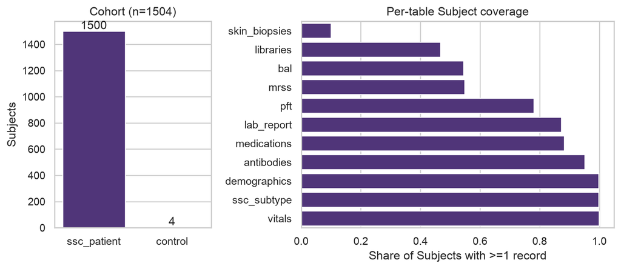

## A hidden second cohort

4 subject IDs (`SSC_NORM_0101/0102/0104/0110`) appear in `libraries.csv` — but **never** in the Registry.

- `libraries.csv`’s own comments confirm these are “healthy control sample[s]”
- Modeled explicitly as an attribute (`ssc_patient` vs `control`)
- Not a data error
- The QC key-linkage check automates this: confirms all 4 against the known set, and would flag any *future* out-of-Registry `subject_id`.

- `lab_report`, `vitals`, `mrss`, `bal`, `medications`, `skin_biopsies` — structured longitudal event records.
- `demographics`/`ssc_subtype` — static, one row per patient

# The Application

- **Data & Dictionary** — schema, coverage, QC report link
- **Cohort Overview** — population-level distributions
- **Compare & Discover** — free-form variable picker across any table/level, with a Control Subject overlay toggle
- **Patient Trajectory** — one/several patient’s longitudinal record
- **QC Report** - data QC metrics generated on the fly

Login + data encryption + audit logging gated behind a published demo account (details in Design Decisions).

[nw-ssc-de.streamlit.app](https://nw-ssc-de.streamlit.app/)

## Data & Dictionary

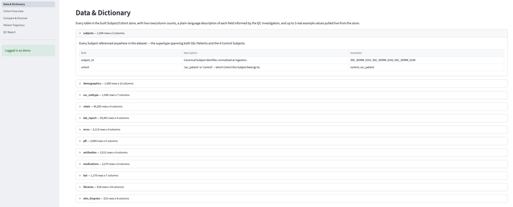

Data & Dictionary tab: every table’s row/column counts, plain-language field descriptions, and live example values

## Cohort Overview

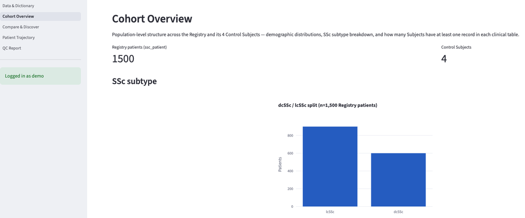

Cohort Overview tab

## Compare & Discover

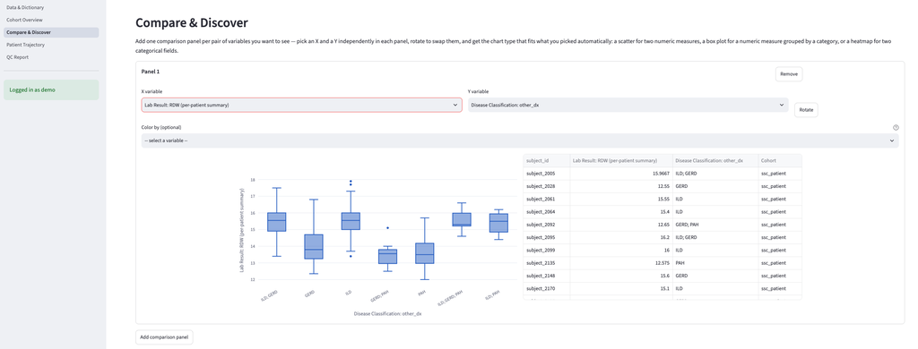

Compare & Discover tab

## Patient Trajectory

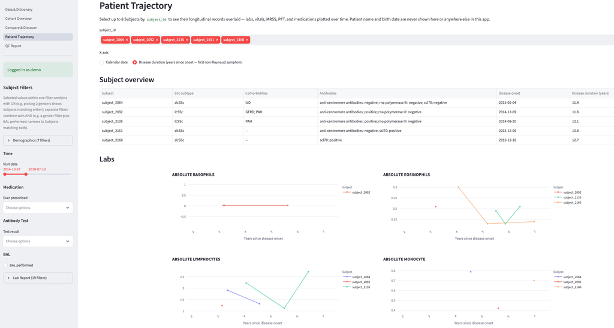

Patient Trajectory tab

# Data-Quality Issues and Analytical Findings

## Height recorded in mixed units

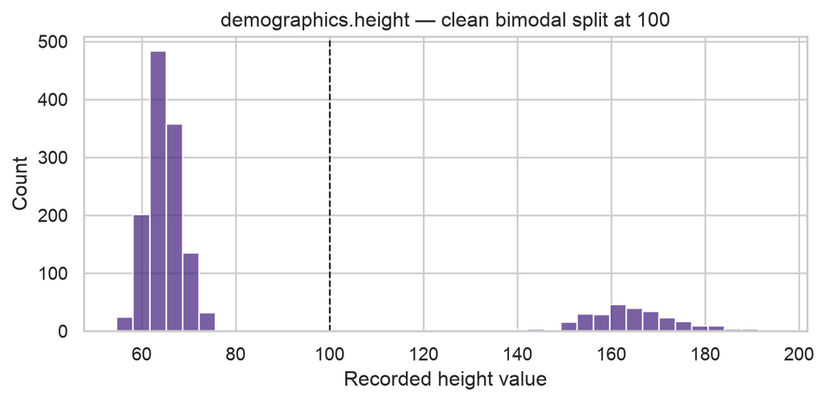

1,235 of 1,500 patients in **inches** (54.7-78.5); the other 265 in **centimeters** (141.3-194.7 cm). Fixed at ingestion: cm-scale values converted to inches, raw CSV left untouched.

## One high-confidence data-entry error

`demographics.csv` lists `subject_8545`’s weight as **22.5** (impossible for a living adult). All 5 separate `vitals.csv` visits spanning 2017-2020 report ~160.6 lbs for the same patient - likely placeholder.

**Decision:** flagged in the QC report without correction or drop.

## A synthetic-data placeholder, not a clinical signal

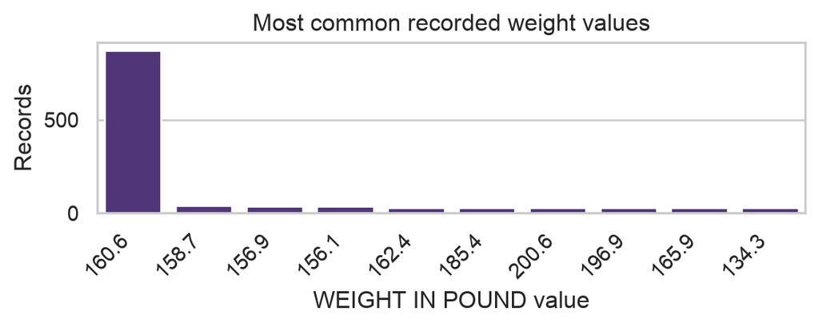

`WEIGHT IN POUND = 160.6` appears 870 times across 195 distinct patients — the next most common value appears only 39 times. Some patients show this exact value on *every* visit across multiple years.

`check_constant_value_across_visits`: flags a value dominating far more patients than expected.

`check_value_spike`: a needle sitting on an otherwise ordinary distribution.

## The same pattern in BP and pulse, measured differently

The per-patient check above is blind to a filler used on only *some* of a patient’s visits. Looking at each value’s share of *every* record instead:

| Measure | Value | Share of all records | vs. local background |
| --- | --- | --- | --- |
| BP SYSTOLIC | 124 | 25% of 7,848 | 11.7x |
| BP DIASTOLIC | 77 | 25% of 7,848 | 5.7x |
| PULSE | 76 | 16% of 8,381 | 4.6x |

## PFT bounds look like generator clipping

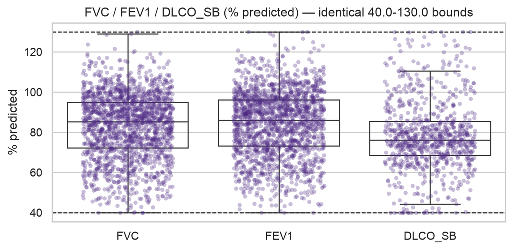

Three physiologically unrelated measures all range **exactly 40.0-130.0%**.

## The same generic check finds real injected errors

Running `check_guideline_range` against `lab_report.csv` surfaces isolated values:

- `ABSOLUTE LYMPHOCYTES`, `MCH`, `MCHC` — one `9999`
- `WBC` — two `999`
- `HEMOGLOBIN`, `NEUTROPHILS`, `LYMPHOCYTES`, `MCV`, `NM BKR ABSOLUTE NEUTROPHIL` — 1-2 negative values each (impossible for any of those measures)

## Medications: names fragmented, doses mostly clean

Only 17 distinct medication strings total — but `CellCept` (192), `mycophenolate mofetil` (211), and `MMF` (189) are the same drug under three names.

- **Dose**: only 24 distinct strings; a few look like intentionally injected errors — negative doses, `999 tablets daily`, `250 g twice daily` (likely a mg/g), `500 mL tablets daily` (a volume unit on a solid dosage form)
- **Two distinct, non-overlapping gaps**: 20 rows have dose but no medication name; 85 rows have medication name but no dose.
- Medication is normalized on every read (split to cannonical medication name, value, unit, frequency)

# Design Decisions and Tradeoffs

## HIPAA controls, implemented literally

Real **login**, real **encryption at rest**, real **audit logging** — despite the data being confirmed synthetic/non-PHI and the deliverable requiring a public repo + public app link.

## Encrypt the store, not the source CSVs

- Keeps the repo **clone-and-run reproducible** — a reviewer can inspect the actual source data directly
- Still gives a real “encryption at rest” component to explain: the runtime SQLite store the app actually reads from is encrypted

## SQLite with a Subject supertype, not pandas end-to-end

```
subjects(subject_id PK, cohort)
 ├─ demographics(subject_id PK/FK)  ─┐  ssc_patient only
 ├─ ssc_subtype (subject_id PK/FK)  ─┘
 └─ 9 clinical tables (subject_id FK)   both cohorts
```

Models the **Control Subject / Registry** relationship correctly — cohort membership, not a foreign-key violation.

## Scope under a 2-day deadline

- Flat package layout over a layered architecture
- Minimal-but-real CI: ruff + mypy + pytest via GitHub Actions
- Targeted tests over exhaustive coverage

# Future Work

Known — not bugs. The app is stable, tested, deployed, green.

- Event overlay (BAL/skin-biopsy dates) on trajectory charts
- Medications are not classified (disease-modifying vs. symptomatic)
- Convert raw values to categorical vareables with thresholds
- Make more flexible data visualization (boxplot vs violin)
- Add direct table views.

## Thank you — discussion

Repo: github.com/sleyn/nw_ssc_data_engineering_protorype

App: [nw-ssc-de.streamlit.app](https://nw-ssc-de.streamlit.app/)

# Appendix

## Appendix: HIPAA-style controls, in detail

- **Login**: gated by a published demo account (`demo` / `SscDemo2026!`) — a demonstration of the control, not a real access boundary
- **Encryption at rest**: the runtime SQLite store is built encrypted from the source CSVs at startup; source CSVs themselves are left plaintext for reviewer reproducibility
- **Audit logging**: every login attempt (success/failure) appended to a local `audit.log` with timestamp and user; does not persist across restarts under the chosen ephemeral hosting (documented limitation)
- Full reasoning: `docs/adr/0001-hipaa-controls-with-public-demo-credentials.md`, `docs/adr/0002-*.md`, `docs/adr/0004-*.md`